# Color Sync in multiple ggplots

## Introduction

I’m building a Shiny app with animal tracking data. There are a lot of plots visualizing the location, time, different animals in the dataset. I colored each animal with a separate color.

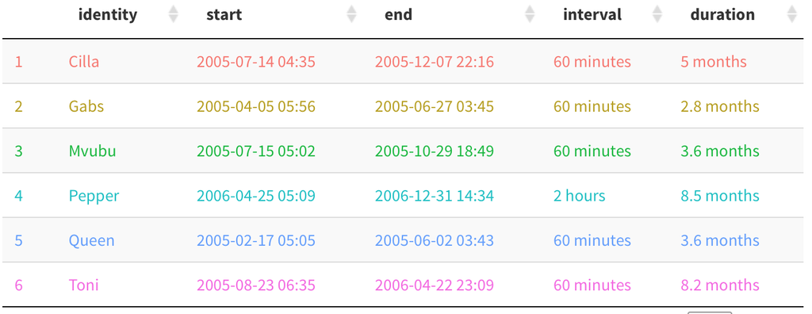

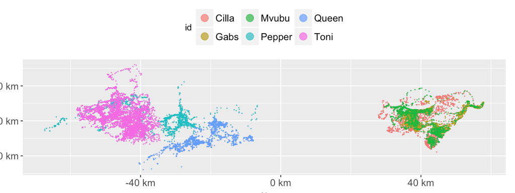

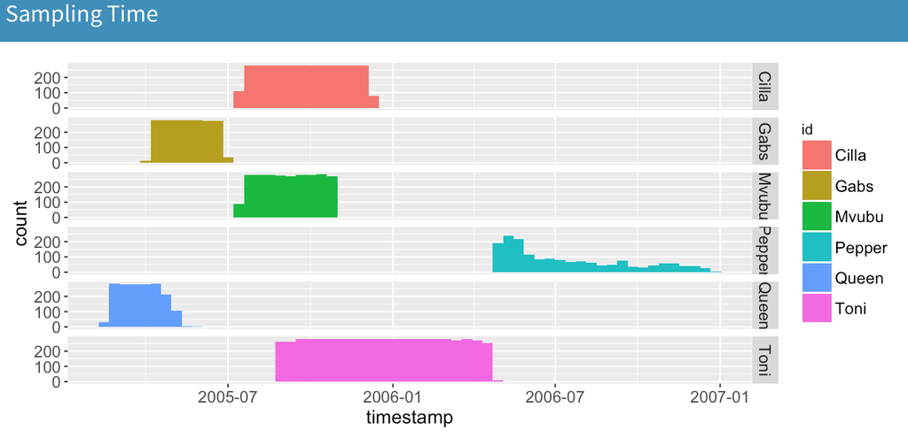

## Colors in subset

Then I let user click rows in table to highlight some animals in plots.

Problem is, ggplot map discrete varible to even spaced colors by default. These are the 6 colors used for 6 values of a discrete variable.

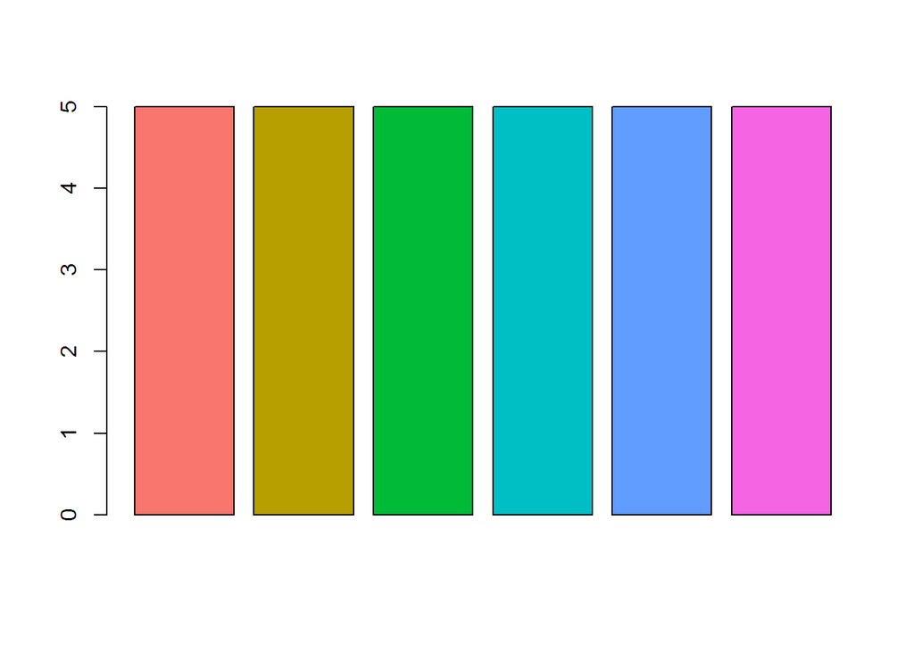

```r
color_bar_plot <- function(color_vec) {
  barplot(rep(5, length(color_vec)), col = color_vec)
}
color_bar_plot(hue_pal()(6))
```

These are 2 colors for 2 values.

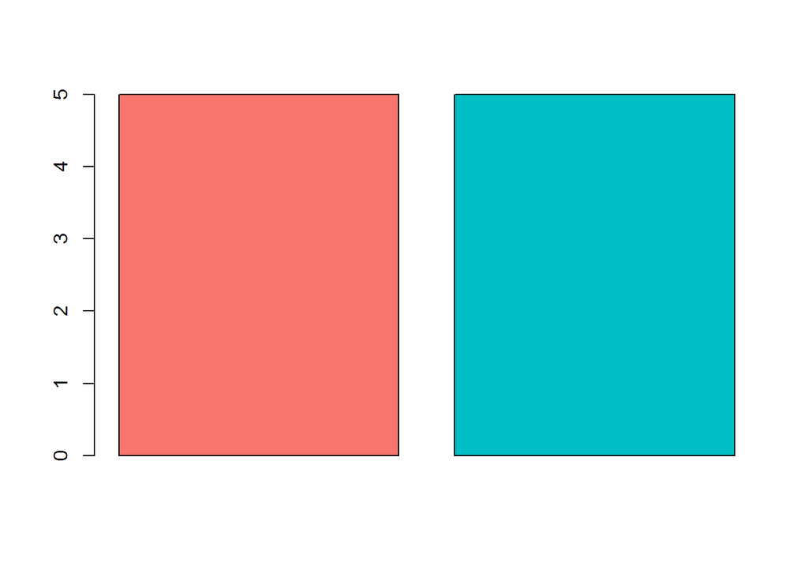

```r
color_bar_plot(hue_pal()(2))
```

So when user selected 2 animals in table, the scatter plot showed them in totally different colors, which is very confusing.

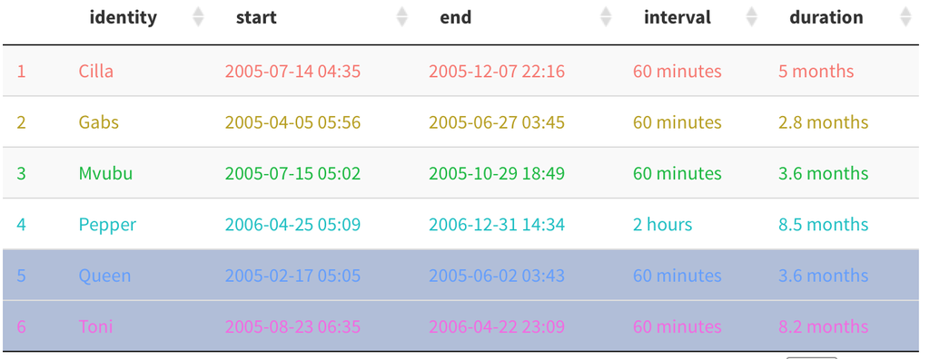

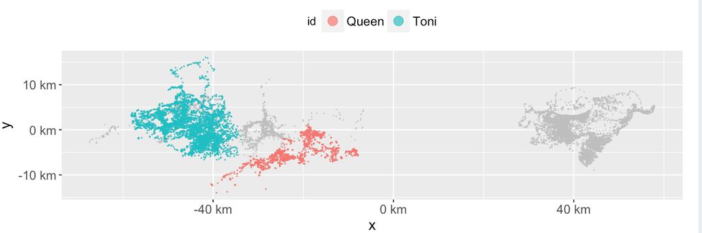

After some search it seemed that I need to provide the color mapping manually. Use `hue_pal()(n)` we can get the n colors mapped to n animals, then I just need to make sure get the mapped colors for every subset then provide them to the plot manually.

```r
selected <- c("Gabs", "Toni")
selected_color <- color_vec[name_vec %in% selected]

ggplot(data = animals, aes(x, y)) +
      geom_point(size = 0.01, alpha = 0.6, colour = "gray") +
      geom_point(size = 0.01, alpha = 0.7,
                 data = animals[identity %in% selected], aes(colour = id)) +
      scale_color_manual(values=selected_color)
```

## New simpler method

I wrote a lot of code maintaining the color mapping in different cases, until today I found that [one simple parameter is enough](https://github.com/tidyverse/ggplot2/issues/1433). It turned out ggplot will drop unused levels for factor variable in color mapping. If we use a `drop = FALSE` parameter the colors will be mapped to all the levels in the factor.

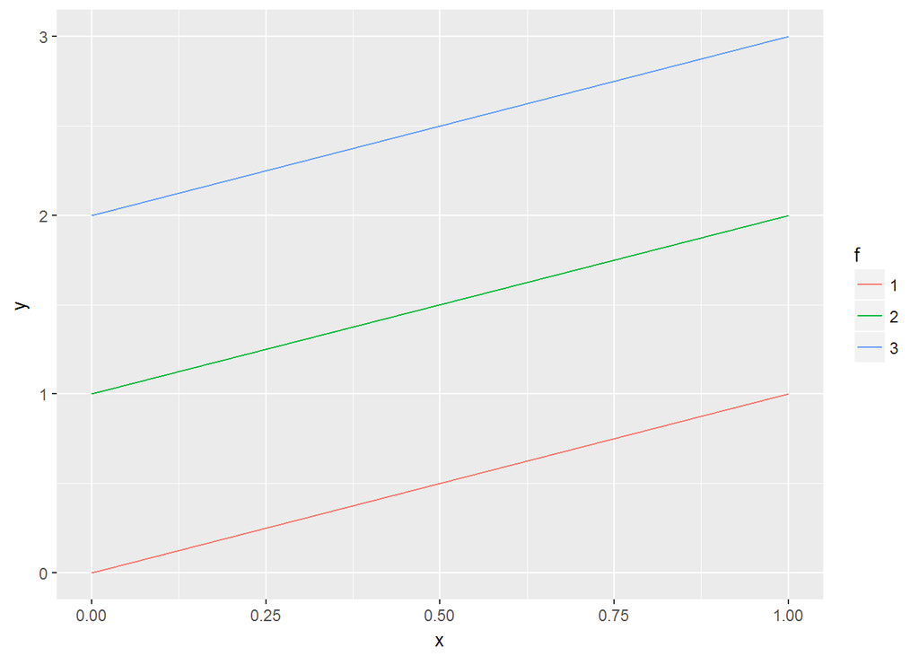

```r
df <- data.frame(
  x = c(0,1,0,1,0,1),
  y = c(0,1,1,2,2,3),
  f = factor(c(1,1,2,2,3,3))
)

ggplot(df, aes(x, y, colour = f)) +
  geom_line()
```

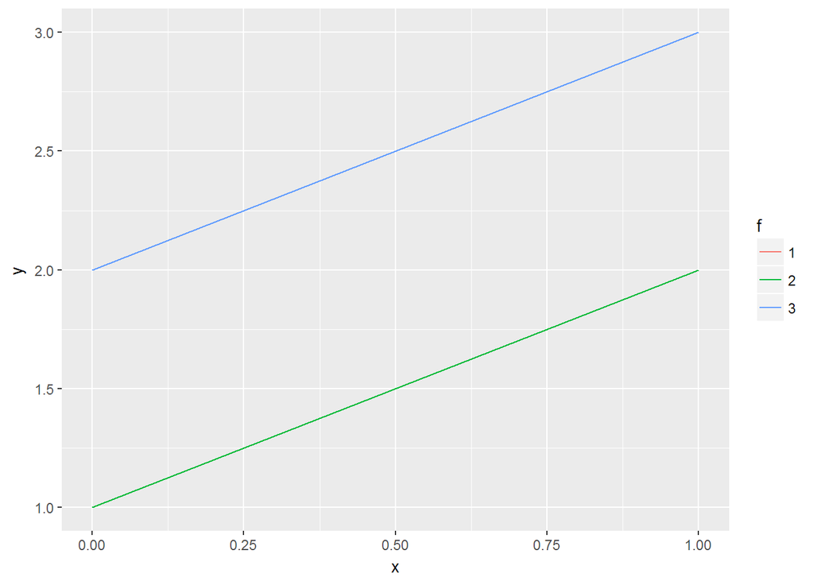

```r
ggplot(subset(df, f != "1"), aes(x, y, colour = f)) +
  geom_line() +
  scale_colour_hue(drop = FALSE)
```

So I only need to make sure the dataset have a factor variable that encoded all levels, then add `scale_colour_hue(drop = FALSE)`. Any subset of data will still have the factor variable with all levels, and the color mapping will be correct.

## New problem with the new method

This is a great improvement to my previous approach, though I met a new problem in this case. I drew a histogram on time, color the bins in histogram, then drew a scatter plot with all points colored by same bins in time. This way user can visualize the time distribution in the locations.

Now there are 14 bins/levels, and they all appear in the scatter plot, even only 8 bins of them have data. So 6 colors listed in scatterplot are unneeded. My previous cumbersome manual method didn’t have this problem because all colors are created manually, unused level didn’t get a mapping.

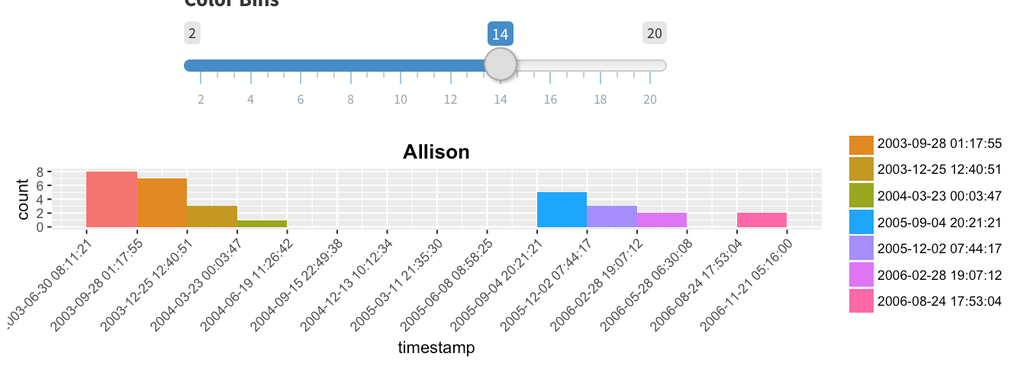

color 6

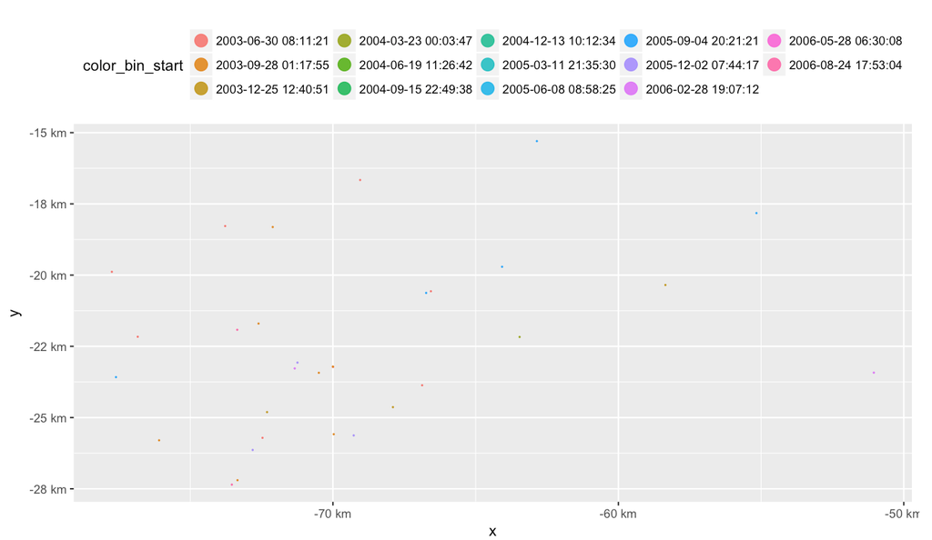

color 7

I read some source code of ggplot but didn’t find how to do this, so I submitted a feature request in ggplot github repo. Hadley asked me to create an new issue with minimal example, so I started to write about the problem.

In the process of writing I looked at more documentations and source code, until I found this paragraph in the help of `discrete_scale`:

> breaks

> This parameter does not affect in any way how the data is scaled - it only affects the appearance of the legend.

This looks like just what I want. It took me a while to realize `discrete_scale` is the more low level function which is supposed to be used internally, and I should use `scale_colour_hue` which can take `discrete_scale` parameters.

So I defined a function to remove the unused levels in color guide. Note we need two functions depend on `color = id` or `fill = id` is used in `aes` call. Now I just add this line with the factor variable and all plots now have the color guide properly.

```r
factor_color <- function(fac) {
  scale_colour_hue(drop = FALSE, breaks = levels(droplevels(fac)))
}
factor_fill <- function(fac) {
  scale_fill_hue(drop = FALSE, breaks = levels(droplevels(fac)))
}
```

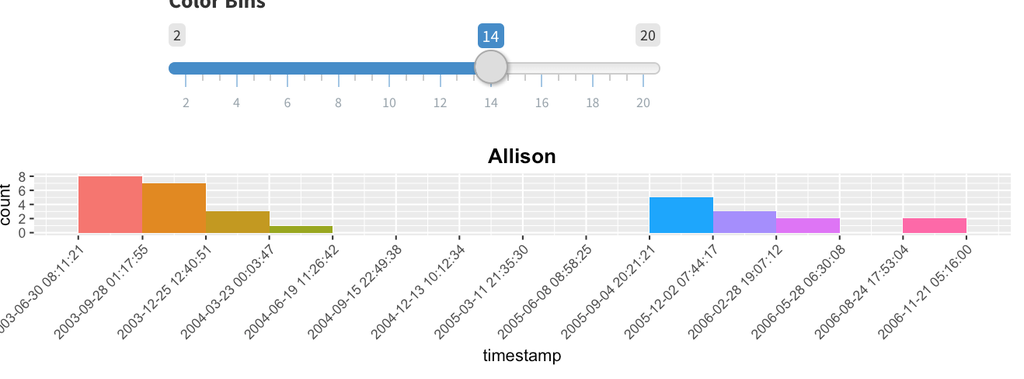

color 8

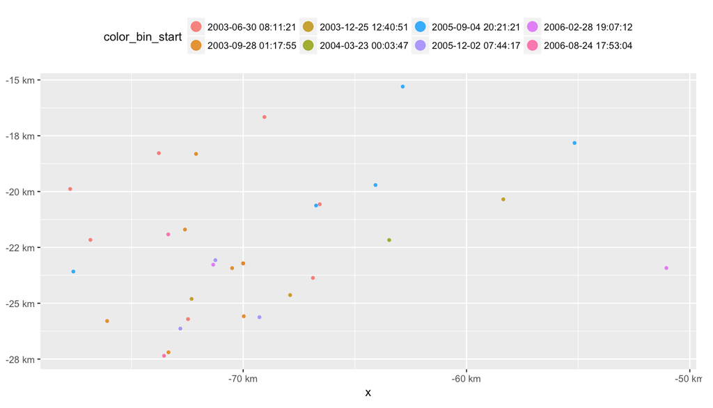

color 9